# CSE204 - Introduction to Machine Learning - Lab Session 5: Exam

[CSE204-2019](https://moodle.polytechnique.fr/course/view.php?id=7862) Lab session #05

Théo Lacombe - Adrien EHRHARDT

Please read the following carefully before starting the exam.

## Overall presentation

This lab exam is composed of 3 exercises, granting up to 5.5, 6 and 9 points, and 2 additional exercises (2 pts each - the final grade is over 20, so there are bonus points).

These exercises are independant.

## Rules and other remarks

Obviously, standard exam rules hold for this lab session, that is no chatting, no use of communication tools, no use of smartphone, etc.

As this is a exam on computer, some details must be specified:

- You are allowed to call the responsible for **technical** (i.e. Python related) help in order to understand an error message if needed (that does not mean that we will debug your code).
- Your answers to written questions (like "What do you observe?") must be **short**, basically one sentence at most (most of the time, a single word would fit perfectly).
- You are allowed to use all standard Python tools along with the `numpy` library. However, you are **not** allowed to use `scikit-learn` except when it is explicitely mentionned in the question. (Basically, it means that if the question is "implement a linear regression", you can't just import the one of `scikit-learn`.)
- You are **not** allowed to have any documents, be it lecture notes / slides or past lab sessions but you are allowed to take into the exam hand-written **notes on a single A4 sheet of paper**(double sided, i.e., you can have notes written front and back)
- You won't be evaluated on the quality of your code, only on its correctness.
- You must **not** change the name of the functions pre-written.
- Beware of the cells you run (and the order you run them); for instance, don't "train" the algorithm of exercise 3 on the data of exercise 2 by mistake!

## Imports

```python
colab_requirements = [
    "matplotlib>=3.1.2",
    "pandas>=0.25.3",
    "numpy>=1.18.1",
    "scikit-learn>=0.22.1",
    "nose>=1.3.7"
]
import sys, subprocess
def run_subprocess_command(cmd):
    # run the command
    process = subprocess.Popen(cmd.split(), stdout=subprocess.PIPE)
    # print the output
    for line in process.stdout:
        print(line.decode().strip())

if "google.colab" in sys.modules:
    for i in colab_requirements:
        run_subprocess_command("pip install " + i)
```

```python
%matplotlib inline
import numpy as np
import pandas as pd
import sklearn as sk
import matplotlib.pyplot as plt

from sklearn.neighbors import KNeighborsClassifier
from sklearn.metrics import accuracy_score
```

```python
def gen_d_regression_samples(n_samples=50, p=3, reg_type='linear'):

    if reg_type=='linear':
        np.random.seed(seed=1)
        x = np.random.uniform(low=0., high=1.5, size=(n_samples, p))
        y = np.sum(x, axis=1) + np.random.normal(scale=0.1, size=n_samples)
        df = pd.DataFrame(x, columns=['x' + str(i) for i in range(p)])
        df['y'] = y
    else:
        np.random.seed(seed=1)
        x = np.random.uniform(low=0., high=1.5, size=(n_samples, p))
        y = np.sum(x, axis=1) + np.sum(x**2, axis=1) + np.random.normal(scale=0.1, size=n_samples)
        df = pd.DataFrame(x, columns=['x' + str(i) for i in range(p)])
        df['y'] = y

    return df
```

# Exercise 1: $k$-nearest neighbors classification

We briefly recall the $k$-nearest neighbors ($k$-NN) algorithm seen in lab session 2, which is a classification method.

Consider a dataset $\mathcal{D} = (X, y)$ where the $k$-th coordinate of the $i$-th observation is denoted by $x^{(i)}_k$ and the corresponding label is $y^{(i)}$, or equilvalently: $$\boldsymbol{X} = \begin{pmatrix} x_1^{(1)} & \dots & x_p^{(1)} \\ \vdots & \dots & \vdots \\ x_1^{(n)} & \dots & x_p^{(n)} \end{pmatrix} \quad \quad \boldsymbol{y} = \begin{pmatrix} y^{(1)} \\ \vdots \\ y^{(n)} \end{pmatrix}.$$

Fix an integer $k$. Given a new observation $x \in \mathbb{R}^p$, we predict its class $\hat{y}$ in the following way.

Let $x^{(i_1)}, \dots, x^{(i_k)}$ be the $k$ observations in $X$ that minimize the Euclidean distance $\|x - x^{(i)}\|_2$. We choose $\hat{y}$ that is the predominant occurence among the corresponding classes $\{ y^{(i_1)}, \dots, y^{(i_k)} \}$. In case of a tie, i.e., two (or more) classes are the most frequent, $\hat{y}$ is chosen randomly (uniformly) among these classes.

We generate some data so that you can test your implementation.

```python
df = gen_d_regression_samples(n_samples=50, p=2)
```

```python
df.head()
```

|  | x0 | x1 | y |
| --- | --- | --- | --- |
| 0 | 0.625533 | 1.080487 | 1.737583 |
| 1 | 0.000172 | 0.453499 | 0.251450 |
| 2 | 0.220134 | 0.138508 | 0.328021 |
| 3 | 0.279390 | 0.518341 | 0.880529 |
| 4 | 0.595151 | 0.808225 | 1.426386 |

## $1$-nearest neighbors classifier

**Question 1 (1pt):** Implement a function that takes as input a matrix `X_train` of shape `n x p`, corresponding labels `y_train` (shape `n`) a new observation `x` of shape `p`, and that returns an prediction of `y_hat` for this new observation using the **one**-nearest neighbor algorithm.

*Python hint:* You can compute the distance between two numpy arrays `x_i` and `x` using `np.linalg.norm(x_i, x)`.

```python
def oneNN(X_train, y_train, x):
    """
        param X_train: np.array, shape N x p
        param y_train: np.array, shape N
        param x:       np.array, shape p
        return: y_hat, class prediction.
    """
    ### BEGIN SOLUTION
    # First, we construct a list of distances from x to each data point in X_train.
    # Each distance is computed using np.linalg.norm(x - x_train).
    # Then, we predict y_hat label by choosing the label of the closest point in X_train (1-NN).
    # The smallest distance is the min in the list. However, we don't need the distance itself but its position.
    # We use np.argmin instead, and finally we look up the corresponding label in y_train and return it.
    y_hat = y_train[np.argmin([np.linalg.norm(x - x_train) for x_train in X_train.to_numpy()])]
    return y_hat
    ### END SOLUTION
```

Test your function by running the following cell

```python
print(oneNN(df[['x0', 'x1']], df['y'], np.array((0,0))))
### BEGIN HIDDEN TESTS
assert int(oneNN(df[['x0', 'x1']], df['y'], np.array((0,0)))) == 0
assert int(oneNN(df[['x0', 'x1']], df['y'], np.array((1,1)))) == 2
### END HIDDEN TESTS
```

```
0.22390487053608235
```

**Question 2 (1pt):** What is the training error achieved by this algorithm in the case $k=1$?

*Hint*: you can try returning `y_hat` from your previous function for `x in X_train` and compare it to `y_train` to give you an idea...

```python
### BEGIN SOLUTION
# We construct a list of predictions using oneNN classifier for each x_test data point in df, and convert it to a numpy array.
# Then, we subtract df['y'], the correct labels, from the predicted labels, and check if the result is 0. 0 means no error.
# Finally, np.all verifies if all the entries in the resulting array evaluate to True (no error).
np.all([oneNN(df[['x0', 'x1']], df['y'], x_test) for x_test in df[['x0', 'x1']].to_numpy()] - df['y'] == 0)
### END SOLUTION
```

```
True
```

The training error is 0 since in the training sample, the nearest-neighbor of a point is itself.

## $k$-nearest neighbors classifier

**Question 3 (1pt):** Is the $k$-NN algorithm a *parametric* or *non-parametric* model?

$k$-NN is a non-parametric model.

### Iris dataset

We now consider the `iris` dataset of $n = 150$ points, with $3$ labels 'setosa', 'versicolor', and 'virginica', encoded respectively by $0, 1, 2$ in the following. This dataset is split in a training set `x_train, y_train` with $3/4$th of the $150$ observations, and a test set `x_test, y_test` of $1/4$th of the $150$ observations; this dataset must be loaded by running the following cell.

```python
from sklearn import datasets
from sklearn import model_selection
iris = datasets.load_iris()
X = iris.data[:, :2]
y = iris.target
```

```python
np.random.seed(seed=1)
x_train, x_test, y_train, y_test = sk.model_selection.train_test_split(X,
                                                                       y,
                                                                       test_size=1/4,
                                                                       random_state=1)
```

**Question 4 (1pt):** In this question, we allow the use of the `scikit-learn` library.

**4.a.** Using the library, perform $k$-NN classification for all $k = 1 \dots 20$ by training on (`x_train`, `y_train`), and use it to predict labels for `x_train` and `x_test`. Evaluate the quality of the classification using the `accuracy_score` function provided by `scikit-learn`. Store the results in two lists, `accuracy_scores_train` and `accuracy_scores_test`, which should contain, for $k = 1 \dots 20$, the error rate (evaluated by `accuracy_score`) on `x_train` and `x_test` respectively.

We recall how to perform $k$-NN classification using `scikit-learn`:

- `clf = KNeighborsClassifier(n_neighbors=k)` creates an object `clf` of the class `classifier`, which can be used to perform `n_neighbors`-NN classification (of course, you have to provide the value of `k` when instantiating the classifier).
- `clf.fit(x_train, y_train)` trains this classifier on a training set, where `x_train` is the observation matrix, `y_train` are the labels.
- `y_pred = clf.predict(x_test)` for a new set of observations, encoded as a matrix `x_test`, returns label predictions `y_pred`.
- `accuracy_score(y_true, y_pred)` given the true labels of the test set `y_true` (`y_test` here) and the labels `y_pred` predicted by the $k$-NN classifier, computes the accuracy score of the classification.

```python
accuracy_scores_train = []
accuracy_scores_test = []
### BEGIN SOLUTION
# We loop for k in range 1 to 21 (range in Python doesn't include the right endpoint, so the interval is without 21)
# We instantiate KNeighborsClassifier with k neighbors.
# We fit the classifier.
# We append the accuracy score on the predictions of the classifier on both training and test sets,
# to accuracy_scores_train and accuracy_scores_test lists, respectively.
for k in range(1,21):
    clf = KNeighborsClassifier(n_neighbors=k)
    clf.fit(x_train, y_train)
    accuracy_scores_train.append(accuracy_score(y_train, clf.predict(x_train)))
    accuracy_scores_test.append(accuracy_score(y_test, clf.predict(x_test)))
### END SOLUTION
```

```python
assert len(accuracy_scores_train) == 20
assert np.max(accuracy_scores_train) < 1
assert np.min(accuracy_scores_train) > 0
```

You can plot the accuracies on the same graph w.r.t. to $k$ using the following cell:

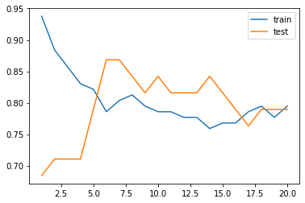

```python
plt.plot(range(1,21), accuracy_scores_train, label='train')
plt.plot(range(1,21), accuracy_scores_test, label='test')
plt.legend()
plt.show()
```

**N.B.:** Note that 1-NN training error *can* be above 0 (like here) if two identical samples (in terms of covariates) have different class labels.

**4.b. (0.5pt)** Which value of $k$ reaches the best accuracy on the test set?

$k = 6, 7$ works best.

**4.c. (0.5pt)** What is the phenomenon you are witnessing for $k > 7$?

Underfitting.

**4.d. (0.5pt)** What is the phenomenon you are witnessing for $k < 6$?

Overfitting.

# Exercise 2: Linear regression and its extensions

We briefly recall the framework of linear regression.

Consider observations $x = x^{(1)} \dots x^{(n)}$, with $x^{(i)} \in \mathbb{R}^p$, and labels $y^{(1)} \dots y^{(n)}$. Given an observation $x^{(i)}$, and a vector $\theta = (\theta_0 \dots \theta_p)^T$, we produce an estimation $\hat{y}^{(i)}$ of $y^{(i)}$ of the following form: $$ \hat{y}^{(i)} = \theta_0 + \theta_1 x^{(i)}_1 + \dots + \theta_p x^{(i)}_p.$$

## Vanilla linear regression

Again, we take the data we sampled for the first regression exercise:

```python
df = gen_d_regression_samples(n_samples=200, p=2)
```

**Question 1: (1pt)** Implement a function `pred` that, given an observation `x` of shape `p` and a vector `theta` of shape `p+1`, returns a predicted value `y_hat`.

*Hint:* Do not forget the constant term $\theta_0$: `1` has to be "added" to `x` in `pred` function.

```python
def pred(x, theta):
    """
        param x:     np.array of shape p
        param theta: np.array of shape (p+1)
    """
    ### BEGIN SOLUTION
    # First, we add a bias term (IMPORTANT!) to our data point x, a p-dimensional vector, which also makes its shape p+1.
    # Second, we compute a dot product of the extended x vector with the theta vector, the weights.
    # We return the prediction given by this regression model.
    return np.dot(np.concatenate((np.array([1]), x), 0), theta)
    ### END SOLUTION
```

```python
assert pred(np.array([0]), np.array([0,0])) == 0
### BEGIN HIDDEN TESTS
assert pred(np.array([1]), np.array([1,1])) == 2
### END HIDDEN TESTS
```

We gather all samples in matrices $\boldsymbol{X}$ and $\boldsymbol{y}$, where $$ \boldsymbol{X} = \begin{pmatrix} x_1^{(1)} & \dots & x_p^{(1)} \\ \vdots & \vdots & \vdots \\ x_1^{(n)} & \dots & x_p^{(n)} \end{pmatrix} \quad \text{and} \quad \boldsymbol{y} = \begin{pmatrix} y^{(1)} \\ \vdots \\ y^{(n)} \end{pmatrix}. $$

We propose a loss function $E(\theta) := \| y - X^T \theta\|^2_2$ which is the sum of squared errors (differences between the true and predicted value for each $x$ in $X$).

**Question 2: (1pt)** Implement a function `E` that, given `X, y, theta` computes the error $E(\theta)$ (you can use `pred` function).

*Python hint:* You can compute the distance between two vector `y_hat` and `y` using `np.linalg.norm(y_hat - y)`.

```python
def E(X, y, theta):
    """
        :param X:     np.array of shape N x p
        :param y:     np.array of shape N
        :param theta: np.array of shape (p+1)
        :return:      float, evaluation of the error function.
    """
    ### BEGIN SOLUTION
    # First, we construct a list of predictions by calling pred function on the x data point with theta weights vector.
    # Then, we subtract y, the correct output vector, and compute the distance using np.linalg.norm
    # We return squared distance.
    return np.linalg.norm([pred(x, theta) for x in X] - y) ** 2
    ### END SOLUTION
```

```python
assert int(E(df[['x0', 'x1']].to_numpy(), df['y'], np.array([0,0,0]))) == 550
### BEGIN HIDDEN TESTS
assert int(E(df[['x0', 'x1']].to_numpy(), df['y'], np.array([1,1,1]))) == 202
### END HIDDEN TESTS
```

We want to find an optimal vector $\theta^*$ so that the loss made by using $\hat{y}^{(i)}$ to approximate $y^{(i)}$ is small. With vector notations, it reads: $$\theta^* \in \mathrm{argmin} (E(\theta)).$$

Since $E(\theta)$ is convex, $\theta^\star$ exists and is unique.

Recall that to find $\theta^\star$, a straightforward solution is to differentiate $E(\theta)$ so as to obtain its gradient, set it to 0 and solve the resulting equation.

This yields a closed form, namely the optimal $\theta^\star$ is given by: $$ \theta^\star = (X^T X)^{-1} X^T y$$

**Question 3: (1pt)** Implement a function `linreg` that, given `X` and `y`, returns the vector optimal `theta`.

*Python hints* :

- You can use `np.linalg.inv(A)` to compute the inverse of a (non-singular) **square** matrix.
- You can use `np.transpose(A)` or equivalently `A.T` to compute the transpose of a numpy array `A`.
- You can use `np.dot(A,B)`, or equivalently `A.dot(B)` to compute the matrix-matrix (or matrix-vector) $A \cdot B$ product between two numpy arrays `A` and `B`. Beware of the shapes!

```python
def linreg(X, y):
    """
        param X: np.array of shape N x (p+1)
        param y: np.array of shape N
        return:  np.array of shape (p+1)
    """
    ### BEGIN SOLUTION
    # First, we compute X^T*X
    # Second, the inverse: (X^T*X)^(-1)
    # Third, X^T*y
    # Finally, we return (X^T*X)^(-1) * X^T*y
    XX = np.dot(X.T, X)
    invXX = np.linalg.inv(XX)
    Xy = np.dot(X.T, y)
    return np.dot(invXX, Xy)
    ### END SOLUTION
```

Test your code with the following code:

```python
linreg(np.concatenate((np.ones(df.shape[0]).reshape(-1, 1), df[['x0', 'x1']].to_numpy()), axis=1), df['y'])
### BEGIN HIDDEN TESTS
assert round(linreg(np.concatenate((np.ones(df.shape[0]).reshape(-1, 1), df[['x0', 'x1']].to_numpy()), axis=1), df['y'])[1], 1) == 1
assert round(linreg(np.concatenate((np.ones(df.shape[0]).reshape(-1, 1), df[['x0', 'x1']].to_numpy()), axis=1), df['y'])[2], 1) == 1
### END HIDDEN TESTS
```

Plot you solution, to see if you're happy with your result, with the following code:

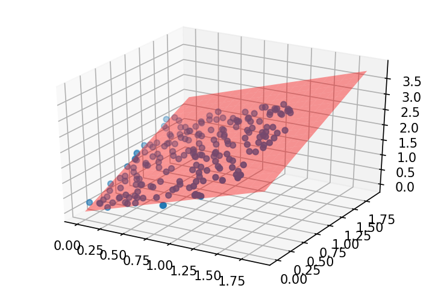

```python
# Imports
from mpl_toolkits.mplot3d import Axes3D
fig = plt.figure(dpi=150)
ax = fig.gca(projection='3d')

# Plotting our data
ax.scatter(df[['x0']].to_numpy(), df[['x1']].to_numpy(), df['y'].to_numpy())

# Creating a mesh
x_surf = np.arange(0, 2, 0.1)
y_surf = np.arange(0, 2, 0.1)
x_surf, y_surf = np.meshgrid(x_surf, y_surf)
exog = pd.core.frame.DataFrame({'x0': x_surf.ravel(), 'Radio': y_surf.ravel()})

# Prediction on the mesh (NOTE: this is bad practice since the coefficients are recalculated for each new prediction)
out = [pred(x,
      linreg(np.concatenate((np.ones(df.shape[0]).reshape(-1, 1),
                             df[['x0', 'x1']].to_numpy()),
                            axis=1), df['y'])) for x in exog.to_numpy()]

# Plotting
ax.plot_surface(x_surf, y_surf,
                np.array(out).reshape(x_surf.shape),
                rstride=1,
                cstride=1,
                color='red',
                alpha = 0.4);
```

## Polynomial regression

We consider the specific case where the observations $x^{(i)}$ are real-valued (that is $p=1$). For an integer $k$ fixed, and a vector $\theta = (\theta_0 \dots \theta_k)^T$, we propose to estimate $y^{(i)}$ in the following way: $$ \hat{y}^{(i)} = \theta_0 + \theta_1 x^{(i)} + \theta_2 (x^{(i)})^2 + \dots + \theta_k (x^{(i)})^k. $$ Here, $(x^{(i)})^j$ means the $j$-th power of $x^{(i)}$.

As in standard linear regression, the goal is to find a $\theta^*$ so that $$ \sum_{i=1}^n (y^{(i)} - \hat{y}^{(i)})^2 $$ is minimal.

```python
df = gen_d_regression_samples(n_samples=100, p=1, reg_type='polynomial')

X = df['x0'].to_numpy()
y = df['y'].to_numpy()

x_train, x_test, y_train, y_test = sk.model_selection.train_test_split(X,
                                                                       y,
                                                                       test_size=1/4,
                                                                       random_state=1)
```

**Question 4 (1pt):** Write a function `polynomial_expand` that, given a **real valued** vector $x \in \mathbb{R}^n$ and an integer $k$, returns the $n \times (k+1)$ matrix $$X = \begin{pmatrix} 1 & x^{(1)} & \dots & (x^{(1)})^k \\ \vdots & \vdots & \dots & \vdots \\ 1 & x^{(n)} & \dots & (x^{(n)})^k \end{pmatrix}$$

```python
def polynomial_expand(x, k):
    """
        param x: np.array of shape N
        param k: integer
        return:  np.array of shape N x (k+1)
    """
    ### BEGIN SOLUTION
    # First, we create a list of powers of x from 0 up to k+1 (without k+1).
    # The list has k+1 elements, each of which is an N-dimensional vector.
    # x ** 0 gives us the vector of 1s.
    # Then, we convert it to a numpy array.
    # We transpose it, because the array we obtained from the list has (k+1) rows and N columns.
    return np.array([x ** i for i in range(k+1)]).T
    ### END SOLUTION
```

```python
### BEGIN HIDDEN TESTS
assert np.all(polynomial_expand(x_train, 10) == np.array([x_train**i for i in range(10+1)]).T)
### END HIDDEN TESTS
```

**Question 5:** Solve the following questions using the functions that you have written above.

**5.a. (1pt)** Perform a polynomial regression to fit `x_train, y_train` ; with $k = 1 \dots 10$ and then predict labels for for the test set `x_test`.

The test error is defined as $$ E_\mathrm{test} (\hat{\boldsymbol{y}}_\mathrm{test}, \boldsymbol{y}_\mathrm{test}) = \|\hat{\boldsymbol{y}}_\mathrm{test} - \boldsymbol{y}_\mathrm{test}\|_2^2, $$ where $n_\mathrm{test}$ is the number of observation in the test set, $\boldsymbol{y}_\mathrm{test}$ is the vector of all the values we're trying to predict from all the samples in `x_test` and $\hat{\boldsymbol{y}}_\mathrm{test}$ is the vector of values what we're predicting.

Store the training errors and test errors you obtain in two lists of size $10$, whose names must be (respectively) `train_errors` and `test_errors`, and such that `train_errors[k]` (resp. `test_errors[k]`) gives the training error (resp. test error) obtained by performing polynomial regression with maximal degree $k$.

```python
#train_errors = ... #<--to uncomment and to complete
#test_errors = ... #<--to uncomment and to complete

### BEGIN SOLUTION
# We intialize two empty lists for train and test errors, respectively.
# We loop over different values of k from 1 to 11 (without 11).
# In the loop:
#   We expand train and test data points to the vector space of polynomials of degree k, respectively.
#   We compute the weights for regression model using linreg function programmed before.
#   Finally, we compute the error using E cost function defined before, and the learnt theta vector.
#   We store these errors separately for the train data, and for test data, by appending them to train_errors and test_errors lists.
train_errors = []
test_errors = []
for k in range(1, 11):
    x_train_poly = polynomial_expand(x_train, k)
    x_test_poly = polynomial_expand(x_test, k)
    theta = linreg(x_train_poly, y_train)
    train_errors.append(E(x_train_poly[:,1:], y_train, theta))
    test_errors.append(E(x_test_poly[:,1:], y_test, theta))
### END SOLUTION
```

```python
### BEGIN HIDDEN TESTS
assert len(train_errors) == 10
assert len(test_errors) == 10
### END HIDDEN TESTS
```

**5.b. (1pt)** Plot both arrays w.r.t. $k$. What is the name of the phenomenon we are observing here? (short answer)

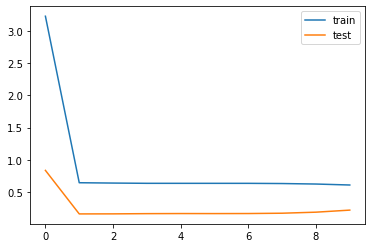

```python
### BEGIN SOLUTION
# We plot train and test errors stored in train_errors and test_errors lists.
# We label the curves, and enable the legend.
# x axis shows different values of k, and y axis shows the loss.
plt.plot(train_errors, label="train")
plt.plot(test_errors, label="test")
plt.legend()
plt.show()
### END SOLUTION
```

Underfitting / overfitting / bias-variance tradeoff.

# Exercise 3: logistic regression

The logistic regression is a common model used to perform binary classification that is actually formulated as a regression problem.

We have a *learning set* $\mathcal{D} = \{\boldsymbol{x^{(i)}}, y^{(i)}\}_{1 \leq i \leq n}$, where $y_i \in \{0,1\}$ and $x_i \in \mathbb{R}^p$.

We consider the logistic function: $$ \sigma : t \mapsto \frac{1}{1 + e^{-t}}.$$ Note that $\sigma$ takes values in $(0,1)$ and will be used to estimate $y^{(i)}$ given $x^{(i)}$. More precisely, given a weight vector $\theta = ( \theta_0 \dots \theta_p )^T$ and a vector $X^{(i)} = (1, x^{(i)}_1 \dots x^{(i)}_p)$, we make the following estimation: $$ \hat{y}^{(i)} = \begin{cases} 1 \text{ if } \sigma(X^{(i)T} \theta) > 1/2 \\ 0 \text{ otherwise } \end{cases} $$

We want to find a good $\theta$. One can show that the optimal $\boldsymbol{\theta}^* = \begin{pmatrix} \theta_0^* & \dots & \theta_p^* \end{pmatrix}^T$ minimizes the following optimization problem:

$$\boldsymbol{\theta}^* \leftarrow \arg\min_{\boldsymbol{\theta}} E(\boldsymbol{\theta}) \quad \text{with} \quad E(\boldsymbol{\theta}) = - \sum_{i=1}^n (1 − y^{(i)}) \ln(1 − \sigma^{(i)}) + (y^{(i)}) \ln(\sigma^{(i)})$$

with

$$ \boldsymbol{X} = \begin{pmatrix} 1 & x_1^{(1)} & \dots & x_p^{(1)} \\ \vdots & \vdots & \dots & \vdots \\ 1 & x_1^{(n)} & \dots & x_p^{(n)} \end{pmatrix} \quad \quad \boldsymbol{y} = \begin{pmatrix} y^{(1)} \\ \vdots \\ y^{(n)} \end{pmatrix} \quad \quad \boldsymbol{\theta} = \begin{pmatrix} \theta_0 \\ \vdots \\ \theta_p \end{pmatrix} $$

**Question 1: (1pt)** Does the error function $E$ have a unique minimum?

$E(\theta)$ is convex so it has a unique minimum.

Let's reload the iris data:

```python
iris = datasets.load_iris()
X = iris.data[:, :2][np.where([target in [0, 1] for target in iris.target])[0]]
y = iris.target[np.where([target in [0, 1] for target in iris.target])[0]]
np.random.seed(seed=1)
x_train, x_test, y_train, y_test = sk.model_selection.train_test_split(X,
                                                                       y,
                                                                       test_size=1/4,
                                                                       random_state=1)
```

**Question 2:**

**2.a. (1pt)** Implement a function `sigma` that compute, given $x^{(i)} \in \mathbb{R}^p$ and $\theta \in \mathbb{R}^{p+1}$ the quantity $\sigma(X^{(i)T} \theta)$.

```python
def sigma(x, theta):
    """
        param x:     np.array of shape p
        param theta: np.array of shape (p+1)
        return:      float.
    """
    ### BEGIN SOLUTION
    # We add the bias term to x vector (IMPORTANT!).
    # Then, we compute a dot product of extended x vector and theta vector.
    # Finally, we compute the value of sigmoid function.
    return 1 / (1 + np.exp(-np.dot(np.concatenate((np.array([1]), x), 0), theta)))
    ### END SOLUTION
```

```python
assert sigma(X[0,:], np.array([0,0,0])) == 0.5
### BEGIN HIDDEN TESTS
assert round(sigma(X[0,:], np.array([1,1,1])),1) == 1
### END HIDDEN TESTS
```

**2.b. (1pt)** Implement a function `pred` that provides, given $x^{(i)} \in \mathbb{R}^p$ and $\theta \in \mathbb{R}^{p+1}$, an estimate $\hat{y}^{(i)}$ of $y^{(i)}$.

```python
def pred(x, theta):
    """
        param x:     np.array of shape p
        param theta: np.array of shape p+1
        return:      integer, 0 or 1.
    """
    ### BEGIN SOLUTION
    # We program the threshold.
    # We return 1 if the value of sigma is higher than 0.5, 0 otherwise.
    if sigma(x, theta) > 1/2:
        return 1
    else:
        return 0
    ### END SOLUTION
```

```python
assert pred(X[0,:], np.array([1,1,1])) == 1
### BEGIN HIDDEN TESTS
assert pred(X[0,:], np.array([-1,-1,-1])) == 0
### END HIDDEN TESTS
```

**Question 3 (1pt):** Implement the error function we want to minimize $E$, that takes $X, y, \theta$ as arguments.

```python
def E(X, y, theta):
    """
        param X:     np.array of shape N x p
        param y:     np.array of shape N
        param theta: np.array of shape (p+1)
        return: float
    """
    ### BEGIN SOLUTION
    # We initialize loss variable to 0.
    # We apply the loss function definition as stated in the problem.
    # Note that -= comes from the - in the definition of E function.
    loss = 0
    for i in range(X.shape[0]):
        loss -= (1 - y[i]) * np.log(1 - sigma(X[i,:], theta)) + y[i] * np.log(sigma(X[i,:], theta))
    return loss
    ### END SOLUTION
```

```python
E(X, y, np.array([0,0,0]))
### BEGIN HIDDEN TESTS
assert int(E(X, y, np.array([0,0,0]))) == 69
### END HIDDEN TESTS
```

As there is no closed form for the optimal $\theta^*$, we will minimize $E$ using a gradient descent. Compute, either here or on a separate sheet of paper that you will give at the end of the exam, the gradient of $E$.

Recall:

$$ (\boldsymbol{A} + \boldsymbol{B})^T = \boldsymbol{A}^T + \boldsymbol{B}^T $$$$ (\boldsymbol{A} \boldsymbol{B})^T = \boldsymbol{B}^T \boldsymbol{A}^T $$\begin{align} \text{Associativity:} & \quad (\boldsymbol{A} \boldsymbol{B}) \boldsymbol{C} = \boldsymbol{A} (\boldsymbol{B} \boldsymbol{C}) = \boldsymbol{A} \boldsymbol{B} \boldsymbol{C} \\ \text{Non-commutativity:} & \quad \boldsymbol{A} \boldsymbol{B} \neq \boldsymbol{B} \boldsymbol{A} \\ \text{Distributivity:} & \quad \boldsymbol{A} (\boldsymbol{B} + \boldsymbol{C}) = \boldsymbol{A} \boldsymbol{B} + \boldsymbol{A} \boldsymbol{C} \\ & \quad (\boldsymbol{B} + \boldsymbol{C}) \boldsymbol{A} = \boldsymbol{B} \boldsymbol{A} + \boldsymbol{C} \boldsymbol{A} \end{align}

Differential identities for matrices:

\begin{align} d(\boldsymbol{A}) & = 0 \quad \quad \quad \text{if } \boldsymbol{A} \text{ is not function of } \boldsymbol{X} \\ d(a\boldsymbol{X}) & = a d \boldsymbol{X} \quad \quad \text{if } a \text{ is not function of } \boldsymbol{X} \\ d(\boldsymbol{X} +\boldsymbol{Y}) & = d \boldsymbol{X} + d \boldsymbol{Y} \\ d(\boldsymbol{XY}) & = (d \boldsymbol{X}) \boldsymbol{Y} + \boldsymbol{X} (d \boldsymbol{Y}) \\ d(\boldsymbol{X}^T) & = (d \boldsymbol{X})^T \\ \end{align}

Let's develop $E(\boldsymbol{\theta})$:

\begin{align} \nabla E(\boldsymbol{\theta}) & = \nabla \sum_{i=1}^n \log ( 1 + \exp( - y^{(i)} X^{(i)} \cdot \theta ) ) \\ & = \nabla - \sum_{i=1}^n (1 − y^{(i)}) \ln(1 − \sigma^{(i)}) + (y^{(i)}) \ln(\sigma^{(i)}) \\ & = - \sum_{i=1}^n (1 − y^{(i)}) \frac{1}{1 - \sigma^{(i)}}(\sigma^{(i)} - 1)\sigma^{(i)} x^{(i)} + (y^{(i)}) \frac{1}{\sigma^{(i)}}\sigma^{(i)}(1-\sigma^{(i)}) x^{(i)} \\ & = - \sum_{i=1}^n x^{(i)} ((y^{(i)} - 1)\sigma^{(i)} + (y^{(i)}) (1-\sigma^{(i)})) \\ & = \sum_{i=1}^n x^{(i)}(\sigma^{(i)} - y^{(i)}) \\ & = \boldsymbol{X}(\boldsymbol{\sigma} - \boldsymbol{y})^T \end{align}

Implement a function `grad_E(X,y,theta)` that returns the gradient (with respect to $\theta$) of $E$ for the current estimation $\theta$ of $E$.

```python
def grad_E(X, y, theta):
    """
        param X:     np.array of shape N x p
        param y:     np.array of shape N
        param theta: np.array of shape (p+1)
        return: np.array of shape (p+1)
    """
    ### BEGIN SOLUTION
    # First, we compute the value of sigma function for theta weights for each x in X
    # Second, we add a column of 1s for biases.
    # Finally, we compute X^T * (sigma - y).
    # Note here, that our matrices have a different orientation of the columns/rows than in the formula.
    # That's why the transpose is applied on X.
    pred = np.array([sigma(x, theta) for x in X])
    X = np.concatenate([np.ones((X.shape[0])).reshape(-1, 1), X], axis=1)
    return np.matmul(X.T, (pred - y))
    ### END SOLUTION
```

```python
assert len(grad_E(X, y, np.array([0,0,0]))) == 3
### BEGIN HIDDEN TESTS
assert grad_E(X, y, np.array([0,0,0]))[0] == 0
assert grad_E(X, y, np.array([0,0,0]))[1] < 0
assert grad_E(X, y, np.array([0,0,0]))[2] > 0
### END HIDDEN TESTS
```

**Question 4 (1pt):** Complete the following code in order to implement the gradient descent algorithm to minimize $E$ that returns the final estimation of $\theta$ and the evolution of energy over time. The hyper parameters (number of steps, learning rates) are set by default and should not be changed.

Note also that we supposed we are only given $x$, not $X$ so you should reconstruct it.

```python
def grad_descent(X, y, eta=0.001, nb_max_step=1000, stopping_criterion=0.00001):
    """
        param x:                  np.array, input observations, shape N x p
        param y:                  np.array, input labels, shape N (filled with 0 and 1)
        param eta:                float, learning rate.
        param nb_max_step:        int, maximal number of steps done in the gradient descent.
        param stopping_criterion: float, stopping criterion on gradient process.

        return:                   np.array of shape p+1 (theta), list of float (evolution_of_loss)

        Remark: do not change the default values!
    """
    # Storing some useful values
    N, p = X.shape
    # List to store the evolution of E(theta) over steps
    evolution_of_loss = []
    # Store the current value of loss to stop gradient descent
    e = np.inf
    # Initialization of theta
    np.random.seed(seed=1)  # DO NOT change this
    theta = np.random.rand(p+1)

    ### Perform the gradient descent
    for t in range(nb_max_step):

        # Perform a gradient step
        #<-- to complete
        # new_e = ... #<-- to complete, store the loss according to the new parameter theta

        ### BEGIN SOLUTION
        # First, compute a gradient by calling grad_E function
        # Second, we update the theta parameters
        # by taking a step in the direction opposite to the gradient (descent).
        # We use eta as the learning rate.
        # Third, we store the new error in new_e that will later be compared with the previous error in e.
        grad = grad_E(X, y, theta)
        theta = theta - eta*grad
        new_e = E(X, y, theta)
        ### END SOLUTION

        # We stop the gradient descent if the variation in the loss function is small
        if np.abs(new_e - e) < stopping_criterion:
            break  # break allow to exit the for loop
        # otherwise, we just set e = new_e and store it
        else:
            e = new_e
            evolution_of_loss.append(e)

    return theta, evolution_of_loss
```

Test your code with the cell below.

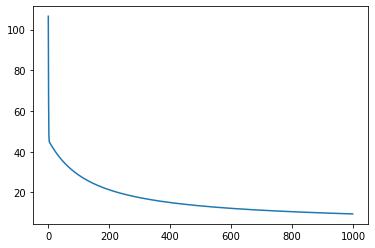

```python
theta, evol = grad_descent(x_train, y_train)
plt.plot(evol);
```

**Question 6:**

**6.a. (1pt)** What is the training error rate (the percentage of predicted labels different from the true ones) of the logistic regression on this dataset?

```python
# training_error =
### BEGIN SOLUTION
# We store predictions for each x in x_train in a numpy array.
# Since the labels have a value of either 0 or 1,
# we can compute the percentage by summing the number of labels that differ
# divided by the total number of labels in y_train.
predictions = np.array([pred(x, theta) for x in x_train])
training_error = np.sum(np.abs(predictions - y_train)) / y_train.shape[0]
### END SOLUTION
```

```python
### BEGIN HIDDEN TESTS
assert round(training_error, 2) == 0.01
### END HIDDEN TESTS
```

**6.b. (1pt)** What is your test error?

```python
# test_error =
### BEGIN SOLUTION
# As above but this time for the test set.
predictions = np.array([pred(x, theta) for x in x_test])
test_error = np.sum(np.abs(predictions - y_test)) / y_test.shape[0]
### END SOLUTION
```

```python
### BEGIN HIDDEN TESTS
assert test_error == 0
### END HIDDEN TESTS
```

# Additional exercise 1

## Cross-validation

(2pts) Perform cross-validation of $k$ for the Titanic dataset.

# Additional exercise 2 (hard)

## Ridge Logistic Regression

(2pts) Add the ridge penalty to the gradient descent algorithm implemented for logistic regression, apply it to the Titanic dataset, and perform cross-validation to choose the amount of penalty.